# Homework 5

# Question 2

```r
set.seed(123)
N <- 200
x1 <- runif(N, -2, 2) # Draw N uniform variables
x2 <- runif(N, -2, 2) # Draw another N variables

# Construct our outcome variable
y <- 2*x1 + 3*x2 + rnorm(N, sd = 2)

df <- data.frame(x1, x2, y)
```

## Part A

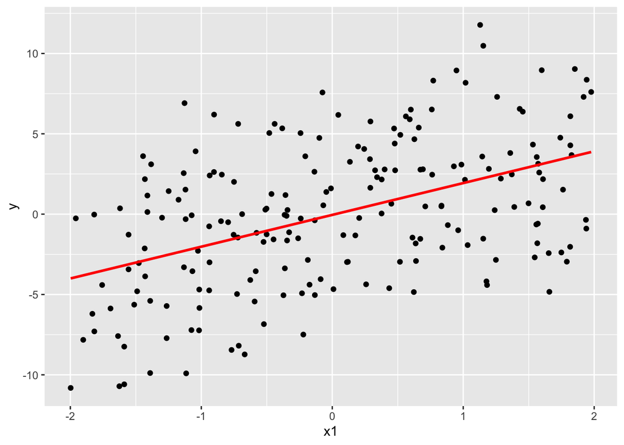

```r
ggplot(df, aes(x1, y)) +
  geom_point() +
  geom_smooth(method = lm, se = FALSE, color = "red")
```

This appears to be a reasonable fit

## Part B

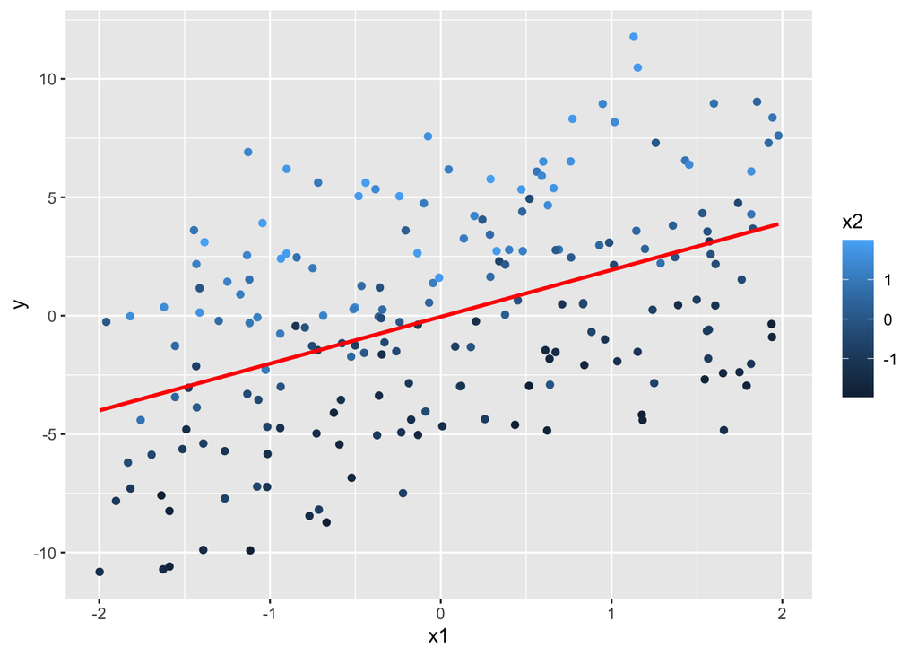

```r
ggplot(df, aes(x1, y, color = x2)) +
  geom_point() +
  geom_smooth(method = lm, se = FALSE, color = "red")
```

The negative values of x2 tend to fall below the line of best fit. Positive residuals means they are above the line of best fit while negative means below the line. A plot with x2 on the x-axis and the residuals on the y-axis would be a relatively positive linear plot since the x2 values are negative for lower residuals and positive for higher residuals.